# PREDICTING BANK TELEMARKETING SUCCESS

Quang Duong

2017-08-19

PREDICTING BANK TELEMARKETING SUCCESS

The success of marketing campaigns can be highly specific to the product, the target audience, and the campaign methods. In this problem, we examine data from direct marketing campaigns of a Portuguese banking institution between May 2008 and November 2010. The marketing campaigns were based on phone calls. Often, more than one contact to the same client was required, in order to access if the product (bank term deposit) would be or not subscribed.

In this analysis, the goal would be predicting the dependent variable y, which takes value 1 if the the client subscribed to a term deposit, and 0 otherwise. The data we will be using bank.csv is a subset of the original data, containing 5000 examples and 20 input variables. The variable information is as follows:

- *age*
- *job* - type of job
- *marital* - marital status
- *education* - Shows the level of education of each customer
- *default* - Whether a customer has credit in default
- *housing* - Does the customer have a housing loan?
- *loan* - Does the customer have a personal loan?
- *contact* - The contact communication type
- *month* - Last contact month of year
- *day_of_week* - Last contact day of Week
- *duration* - Last contact duration in seconds (Note: this variable is not known before making the call)
- *campaign* - Number of contact performed for the client during the campaign
- *pdays* - number of days that passed by after the client was last contacted from a previous campaign (value of 999 means the client was not previously contacted)
- *previous* - number of contacts performed before this campaign and for this client
- *poutcome* - outcome of the previous marketing campaign
- *emp.var.rate* - employment variation rate - quarterly indicator
- *cons.price.idx* - consumer price index - monthly indicator
- *cons.conf.idx* - consumer confidence index - monthly indicator
- *euribor3m* - euribor 3 month rate - daily indicator
- *nr.employed* - number of employees - quarterly indicator

## Problem 1 - Loading the Data

Use the read.csv function to load the contents of bank.csv into a data frame called bank. What is the average age in the data set?

```r
bank <- read.csv("bank.csv")
summary(bank)
```

```
      age                 job           marital
 Min.   :17.00   admin.     :1260   divorced: 498
 1st Qu.:32.00   blue-collar:1170   married :3026
 Median :38.00   technician : 812   single  :1467
 Mean   :39.58   services   : 450   unknown :   9
 3rd Qu.:46.00   management : 368
 Max.   :92.00   retired    : 187
                 (Other)    : 753
               education       default        housing          loan
 university.degree  :1457   no     :3998   no     :2278   no     :4144
 high.school        :1126   unknown:1002   unknown: 118   unknown: 118
 basic.9y           : 759                  yes    :2604   yes    : 738
 professional.course: 634
 basic.4y           : 505
 basic.6y           : 301
 (Other)            : 218
      contact         month      day_of_week    duration
 cellular :3149   may    :1680   fri: 916    Min.   :   1.0
 telephone:1851   jul    : 853   mon:1007    1st Qu.: 105.0
                  aug    : 750   thu:1047    Median : 181.0
                  jun    : 662   tue: 987    Mean   : 265.2
                  nov    : 491   wed:1043    3rd Qu.: 329.0
                  apr    : 341               Max.   :3284.0
                  (Other): 223
    campaign          pdays          previous             poutcome
 Min.   : 1.000   Min.   :  0.0   Min.   :0.0000   failure    : 515
 1st Qu.: 1.000   1st Qu.:999.0   1st Qu.:0.0000   nonexistent:4296
 Median : 2.000   Median :999.0   Median :0.0000   success    : 189
 Mean   : 2.538   Mean   :958.7   Mean   :0.1778
 3rd Qu.: 3.000   3rd Qu.:999.0   3rd Qu.:0.0000
 Max.   :56.000   Max.   :999.0   Max.   :6.0000

  emp.var.rate      cons.price.idx  cons.conf.idx      euribor3m
 Min.   :-3.40000   Min.   :92.20   Min.   :-50.80   Min.   :0.634
 1st Qu.:-1.80000   1st Qu.:93.08   1st Qu.:-42.70   1st Qu.:1.334
 Median : 1.10000   Median :93.44   Median :-41.80   Median :4.857
 Mean   : 0.05834   Mean   :93.57   Mean   :-40.54   Mean   :3.597
 3rd Qu.: 1.40000   3rd Qu.:93.99   3rd Qu.:-36.40   3rd Qu.:4.961
 Max.   : 1.40000   Max.   :94.77   Max.   :-26.90   Max.   :5.045

  nr.employed         y
 Min.   :4964   Min.   :0.0000
 1st Qu.:5099   1st Qu.:0.0000
 Median :5191   Median :0.0000
 Mean   :5166   Mean   :0.1182
 3rd Qu.:5228   3rd Qu.:0.0000
 Max.   :5228   Max.   :1.0000
```

## Problem 2 - Call Durations by Job

Build a boxplot that shows the call duration distributions over different jobs.

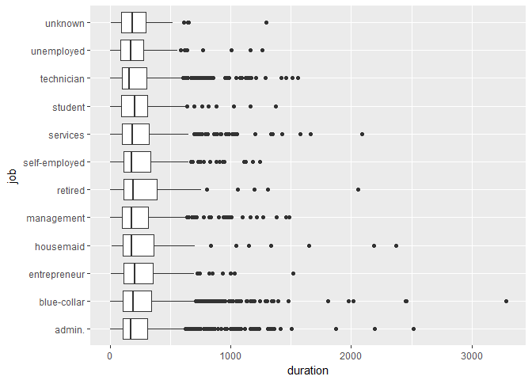

```r
library(ggplot2)
attach(bank)
ggplot() + geom_boxplot(data = bank, aes(job, duration)) + coord_flip()
```

```r
sort(tapply(bank$duration, bank$job, mean))
```

```
   unemployed    technician       unknown       student        admin.
     232.3053      239.9052      248.7222      255.7519      256.5754
   management      services  entrepreneur   blue-collar       retired
     261.0000      269.6022      279.7680      284.4000      285.8770
self-employed     housemaid
     287.3608      303.2542
```

## Problem 3 - Multicolinearity

As good practice, it is always helpful to first check for multicolinearity before running models, especially since this dataset contains macroeconomic indicators. Examine the correlation between the following variables: emp.var.rate, cons.price.idx, cons.conf.idx, euribor3m, and nr.employed.

```r
cor(bank[c("emp.var.rate","cons.price.idx","cons.conf.idx","euribor3m","nr.employed")])
```

```
               emp.var.rate cons.price.idx cons.conf.idx euribor3m
emp.var.rate      1.0000000      0.7808786    0.20449051 0.9732989
cons.price.idx    0.7808786      1.0000000    0.07921100 0.7000698
cons.conf.idx     0.2044905      0.0792110    1.00000000 0.2822054
euribor3m         0.9732989      0.7000698    0.28220537 1.0000000
nr.employed       0.9141299      0.5452224    0.09970857 0.9479813
               nr.employed
emp.var.rate    0.91412988
cons.price.idx  0.54522242
cons.conf.idx   0.09970857
euribor3m       0.94798135
nr.employed     1.00000000
```

## Problem 4 - Splitting into a Training and Testing Set

Obtain a random training/testing set split. Split months into a training data frame called “training” using the observations for which spl is TRUE and a testing data frame called “testing” using the observations for which spl is FALSE.

```r
library(caTools)
set.seed(201)
spl <- sample.split(bank$y, 0.7)
trainSet <- subset(bank, spl==TRUE)
testSet <- subset(bank, spl==FALSE)
```

## Problem 5 - Training a Logistic Regression Model

Train a logistic regression model using independent variables age, job, marital, education, default, housing, loan, contact, month, day_of_week, campaign, pdays, previous, poutcome, emp.var.rate, cons.price.idx, and cons.conf.idx, using the training set to obtain the model. Notice that we have removed duration (since it’s not available before the call, so shouldn’t be used in a strictly predictive model), euribor3m and nr.employed (due to multicolinearity issue).

```r
logReg <- glm(y ~ age + job + marital + education + default + housing + loan + contact + month + day_of_week + campaign + pdays + previous + poutcome + emp.var.rate + cons.conf.idx + cons.price.idx, data = trainSet, family = "binomial")
summary(logReg)
```

```
Call:
glm(formula = y ~ age + job + marital + education + default +
    housing + loan + contact + month + day_of_week + campaign +
    pdays + previous + poutcome + emp.var.rate + cons.conf.idx +
    cons.price.idx, family = "binomial", data = trainSet)

Deviance Residuals:
    Min       1Q   Median       3Q      Max
-2.0070  -0.4412  -0.3237  -0.2409   2.7433

Coefficients: (1 not defined because of singularities)
                               Estimate Std. Error z value Pr(>|z|)
(Intercept)                  -1.142e+02  1.847e+01  -6.183 6.28e-10 ***
age                           1.567e-02  7.227e-03   2.169 0.030118 *
jobblue-collar                1.579e-01  2.193e-01   0.720 0.471487
jobentrepreneur              -5.453e-01  4.039e-01  -1.350 0.176968
jobhousemaid                 -1.103e-01  4.798e-01  -0.230 0.818152
jobmanagement                -2.475e-02  2.469e-01  -0.100 0.920141
jobretired                   -3.763e-02  3.272e-01  -0.115 0.908424
jobself-employed              3.930e-01  3.177e-01   1.237 0.216089
jobservices                   2.249e-03  2.553e-01   0.009 0.992971
jobstudent                    4.922e-01  3.297e-01   1.493 0.135466
jobtechnician                -7.562e-02  2.188e-01  -0.346 0.729563
jobunemployed                -6.709e-01  4.378e-01  -1.533 0.125371
jobunknown                   -1.076e-01  7.446e-01  -0.145 0.885084
maritalmarried                3.128e-01  2.224e-01   1.406 0.159601
maritalsingle                 3.625e-01  2.457e-01   1.475 0.140111
maritalunknown                5.848e-01  1.205e+00   0.485 0.627556
educationbasic.6y             7.062e-03  3.202e-01   0.022 0.982405
educationbasic.9y             9.914e-03  2.530e-01   0.039 0.968744
educationhigh.school         -5.576e-02  2.588e-01  -0.215 0.829383
educationilliterate           1.458e+01  3.247e+02   0.045 0.964179
educationprofessional.course  5.903e-02  2.879e-01   0.205 0.837523
educationuniversity.degree    1.464e-01  2.589e-01   0.566 0.571647
educationunknown             -6.803e-01  3.950e-01  -1.722 0.085020 .
defaultunknown               -4.383e-01  1.973e-01  -2.221 0.026339 *
housingunknown                1.361e-01  3.763e-01   0.362 0.717616
housingyes                    4.583e-02  1.206e-01   0.380 0.703955
loanunknown                          NA         NA      NA       NA
loanyes                      -2.102e-01  1.740e-01  -1.208 0.226947
```

[output cut: 17 more lines]

```
poutcomenonexistent           8.804e-01  2.999e-01   2.936 0.003325 **
poutcomesuccess               4.368e-01  8.555e-01   0.511 0.609598
emp.var.rate                 -8.078e-01  7.625e-02 -10.594  < 2e-16 ***
cons.conf.idx                -5.433e-04  1.549e-02  -0.035 0.972028
cons.price.idx                1.196e+00  1.985e-01   6.024 1.70e-09 ***
---
Signif. codes:  0 '***' 0.001 '**' 0.01 '*' 0.05 '.' 0.1 ' ' 1

(Dispersion parameter for binomial family taken to be 1)

    Null deviance: 2544.5  on 3499  degrees of freedom
Residual deviance: 2031.3  on 3451  degrees of freedom
AIC: 2129.3

Number of Fisher Scoring iterations: 11
```

## Problem 6 - Interpreting Model Coefficients

What is the meaning of the coefficient labeled “monthmar” in the logistic regression summary output?

The coefficients of the model are the log odds associated with that variable; so we see that the odds of subscribing are exp(1.286)=3.618284 those of an otherwise identical contact. This means the contact is predicted to have 3.618284-1=2.618284 higher odds of subscribing.

## Problem 7 - Obtaining Test Set Predictions

Using your logistic regression model, obtain predictions on the test set. Then, using a probability threshold of 0.5, create a confusion matrix for the test set.

We would like to compare the predictions obtained by the logistic regression model and those obtained by a naive baseline model. Remember that the naive baseline model we use in this class always predicts the most frequent outcome in the training set for all observations in the test set.

```r
logPred <- predict(logReg, newdata = testSet, type = "response")
table(trainSet$y)
table(testSet$y)
table(testSet$y, logPred >= 0.5)
```

```
   0    1
3086  414

   0    1
1323  177

    FALSE TRUE
  0  1273   50
  1   133   44
```

What is the number of test set observations where the prediction from the logistic regression model is different than the prediction from the baseline model?

```r
50+44
```

```
[1] 94
```

## Problem 8 - Computing Test-Set AUC

```r
library(ROCR)
logPredROCR <- prediction(logPred, labels = testSet$y)
ROC <- as.numeric(performance(logPredROCR, "auc")@y.values)
ROC
```

```
[1] 0.7507334
```

## Problem 9 - Interpreting AUC

The proportion of the time the model can differentiate between a randomly selected client who subscribed to a term deposit and a randomly selected client who did not subscribe correct

## Problem 10 - ROC Curves

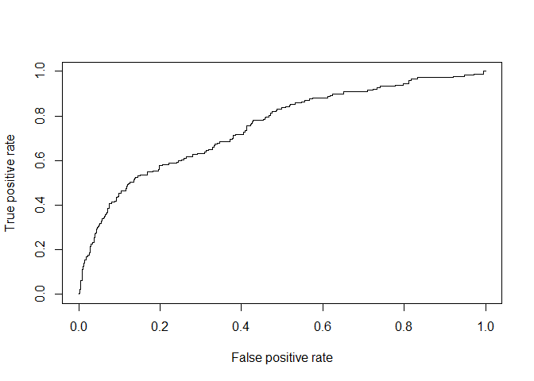

```r
plot(performance(logPredROCR, "tpr", "fpr"))
```

Plot the colorized ROC curve for the logistic regression model’s performance on the test set.

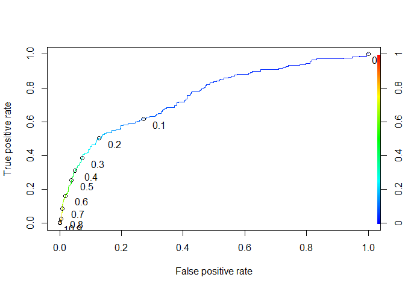

```r
plot(performance(logPredROCR, "tpr", "fpr"), colorize = TRUE, print.cutoffs.at=seq(0,1,0.1), text.adj=c(-0.7,1.2))
```

At roughly which logistic regression cutoff does the model achieve a true positive rate of 60% and a false positive rate of 25%?

From the colorized curve, we can see that the light turqoise color, corresponding to cutoff 0.11, is associated with a true positive rate of about 0.60 and false positive rate of about 0.25.

## Problem 12 - Cross-Validation to Select Parameters

Which of the following best describes how 10-fold cross-validation works when selecting between 4 different parameter values?

In 10-fold cross validation, the model with each parameter setting will be trained on ten 90% subsets of the training set. Hence, a total of 40 models will be trained. The models are evaluated in each case on the last 10% of the training set (not on the testing set).

## Problem 13 - Cross-Validation for a CART Model

Set the random seed to 201 (even though you have already done so earlier in the problem). Then use the caret package and the train function to perform 10-fold cross validation with the training data set to select the best cp value for a CART model that predicts the dependent variable y using the same set of independent variables as in the logistic regression (Problem 5). Select the cp value from a grid consisting of the 50 values 0.001, 0.002, …, 0.05.

What cp value maximizes the cross-validation accuracy?

```r
library(caret)
library(rpart)
cpGrid <- expand.grid(cp = seq(0.001,0.05,0.001))
cpControl <- trainControl(method = "cv", number = 10)
set.seed(201)
train(y ~ age + job + marital + education + default + housing + loan + contact + month + day_of_week + campaign + pdays + previous + poutcome + emp.var.rate + cons.conf.idx + cons.price.idx, data = trainSet, method = "rpart", trControl = cpControl, tuneGrid = cpGrid)
```

```
CART

3500 samples
  17 predictor

No pre-processing
Resampling: Cross-Validated (10 fold)
Summary of sample sizes: 3150, 3150, 3150, 3150, 3150, 3150, ...
Resampling results across tuning parameters:

  cp     RMSE       Rsquared
  0.001  0.3160587  0.11358498
  0.002  0.3112391  0.11992806
  0.003  0.3078711  0.11997539
  0.004  0.3061215  0.12088087
  0.005  0.3015904  0.13503479
  0.006  0.3013035  0.13338237
  0.007  0.2992894  0.14137645
  0.008  0.2991301  0.14232798
  0.009  0.2991301  0.14232798
  0.010  0.2999903  0.13647394
  0.011  0.2999903  0.13647394
  0.012  0.2999493  0.13728686
  0.013  0.3005474  0.13374140
  0.014  0.3012453  0.12927807
  0.015  0.3012453  0.12927807
  0.016  0.3010942  0.13003374
  0.017  0.3010942  0.13003374
  0.018  0.3010942  0.13003374
  0.019  0.3010942  0.13003374
  0.020  0.3010942  0.13003374
  0.021  0.3019095  0.12600844
  0.022  0.3026215  0.12208297
  0.023  0.3036288  0.11499579
  0.024  0.3036288  0.11499579
  0.025  0.3041135  0.11193528
  0.026  0.3041135  0.11193528
  0.027  0.3041135  0.11193528
  0.028  0.3041135  0.11193528
  0.029  0.3041135  0.11193528
```

[output cut: 9 more lines]

```
  0.039  0.3041135  0.11193528
  0.040  0.3041135  0.11193528
  0.041  0.3053300  0.10477598
  0.042  0.3053300  0.10477598
  0.043  0.3053300  0.10477598
  0.044  0.3061503  0.10027299
  0.045  0.3094232  0.08276560
  0.046  0.3098708  0.08013029
  0.047  0.3112410  0.07269873
  0.048  0.3120669  0.06798423
  0.049  0.3120669  0.06798423
  0.050  0.3120669  0.06798423

RMSE was used to select the optimal model using  the smallest value.
The final value used for the model was cp = 0.009.
```

## Problem 14 - Train CART Model

Build and plot the CART model trained with the parameter identified in Problem 13, again predicting the dependent variable using the same set of independent variables. What variable is used as the first (upper-most) split in the tree?

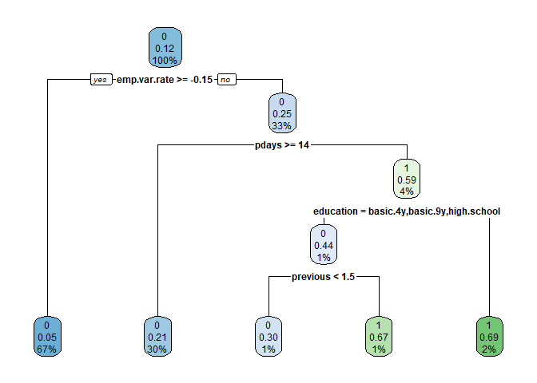

```r
library(rpart)
library(rpart.plot)
treeMod <- rpart(y ~ age + job + marital + education + default + housing + loan + contact + month + day_of_week + campaign + pdays + previous + poutcome + emp.var.rate + cons.conf.idx + cons.price.idx, data = trainSet, method = "class", control = rpart.control(cp = 0.009))
rpart.plot(treeMod)
```

## Problem 15 - Test-Set Accuracy for CART Model

Using the CART model you created in Problem 14, obtain predictions on the test set (using the parameter type=“class” with the predict function). Then, create a confusion matrix for the test set.

What is the accuracy of your CART model?

```r
treePred <- predict(treeMod, newdata = testSet, type = "class")
table(testSet$y, treePred)
(1303+28)/(1303+28+20+149)
```

```
   treePred
       0    1
  0 1303   20
  1  149   28
[1] 0.8873333
```